# Checking the metaBUS correlation matrices with `port`

A forensic screen of 12,547 reported correlation matrices

Published

July 6, 2026

## What this is

A correlation matrix is a genuine (complete-data, single-sample) Pearson matrix only if it is **positive semidefinite** (PSD). But the numbers we see are *rounded*, so the honest question is the **box** question that `port` answers:

> given that every off-diagonal was rounded to two decimals, does **any** PSD matrix exist inside the rounding box around the reported values?

`port` returns one of three verdicts per matrix:

- **`inconsistent`** — no PSD matrix fits the rounding box (a rigorous, floating-point-safe certificate: the reported values cannot be a complete-data Pearson matrix, up to rounding);
- **`consistent`** — a PSD matrix inside the box is exhibited;
- **`undecided`** — precision-limited; the box grazes the PSD boundary.

A caveat for *this* corpus, stated up front: metaBUS matrices are often **meta-analytically assembled** — different cells come from different studies and samples. Such synthetic matrices are *routinely* non-PSD for entirely benign reasons (as are pairwise-deletion, polychoric, and disattenuated matrices). So the headline is **not** the count of inconsistent matrices, but their **severity**: how far past the PSD boundary they sit, which is what separates a benign near-boundary rounding/assembly artefact from a substantive error.

```r
load("../data/raw/matrixList.RData")   # provides `matrixList`

p <- vapply(matrixList, nrow, integer(1))

tibble(matrices = length(matrixList),
       variables_min = min(p),
       variables_median = median(p),
       variables_max = max(p)) |>
  kable(caption = "The corpus")
```

The corpus

| matrices | variables_min | variables_median | variables_max |
| --- | --- | --- | --- |
| 12547 | 3 | 9 | 46 |

### The precision assumption

Nearly all cells are reported to two decimals, so we screen at `decimals = 2` (`delta = 0.005`). This is **sound** for any cell reported to two *or more* decimals: assuming two decimals gives a box at least as wide as the true rounding, so a genuinely valid matrix is never falsely flagged. The only cells it could mishandle are ones truly reported at *one* decimal (a handful of matrices); those we would, if anything, under-flag, never over-flag.

```r
dp <- function(x) { x <- abs(x[!is.na(x)]); k <- 0L
  while (k < 6L && any(abs(x * 10^k - round(x * 10^k)) > 1e-9)) k <- k + 1L; k }

maxdp <- vapply(matrixList, function(M) dp(M[upper.tri(M)]), integer(1))

tibble(`finest decimal place used` = maxdp) |>
  count(`finest decimal place used`) |>
  mutate(`% of corpus` = round(100 * n / sum(n), 1)) |>
  kable(caption = "Reported precision (max decimal places per matrix)")
```

Reported precision (max decimal places per matrix)

| finest decimal place used | n | % of corpus |
| --- | --- | --- |
| 1 | 3 | 0.0 |
| 2 | 11170 | 89.0 |
| 3 | 1241 | 9.9 |
| 4 | 118 | 0.9 |
| 5 | 13 | 0.1 |
| 6 | 2 | 0.0 |

## Screening the whole corpus

`check_corr_psd_batch()` runs the rigorous check over every matrix and returns a tidy table (`id`, `verdict`, `certified`, `margin`, `delta`, `p`, …). This is the one step that touches all 12,547 matrices; it takes a couple of minutes and is cached.

```r
screen <- cache("../data/processed/metabus_screen.rds",
                check_corr_psd_batch(matrixList, decimals = 2, quiet = TRUE))

screen |>
  count(verdict) |>
  mutate(`%` = round(100 * n / sum(n), 1)) |>
  arrange(desc(n)) |>
  kable(caption = "Verdict distribution across the corpus")
```

Verdict distribution across the corpus

| verdict | n | % |
| --- | --- | --- |
| consistent | 11726 | 93.5 |
| inconsistent | 811 | 6.5 |
| undecided | 10 | 0.1 |

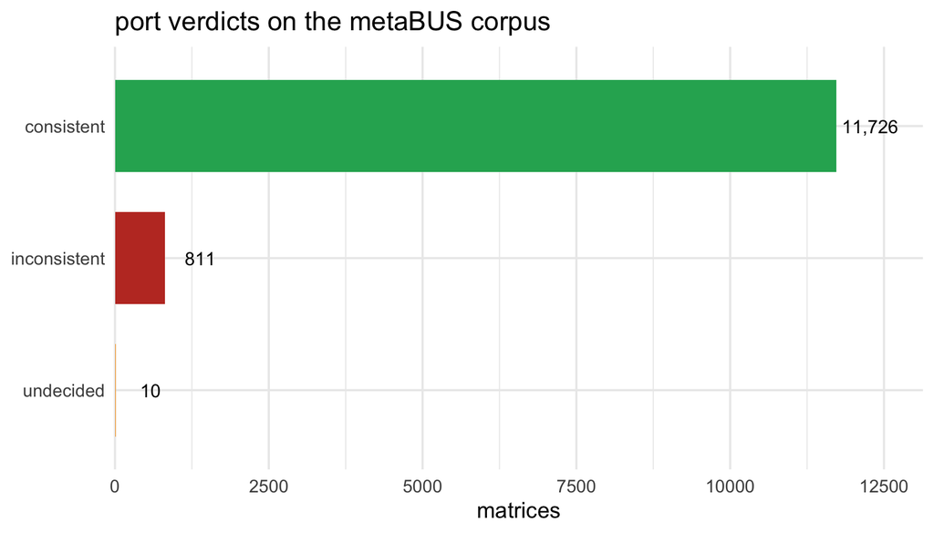

Inconsistency should track matrix size — more variables means more triples that can frustrate one another:

Inconsistent share by matrix size

| p_bin | n | % inconsistent |
| --- | --- | --- |
| 3-4 | 1055 | 0.5 |
| 5-6 | 2240 | 2.2 |
| 7-8 | 2525 | 3.6 |
| 9-10 | 2238 | 5.8 |
| 11-15 | 3063 | 8.4 |
| 16-20 | 982 | 15.9 |
| 21-30 | 402 | 27.9 |
| 31+ | 42 | 26.2 |

## How clear-cut are the inconsistencies?

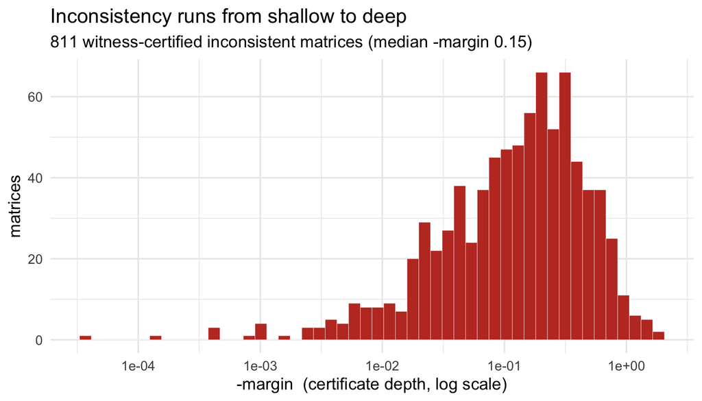

## Severity and localization (resumable, batched deep dive)

The interpretable severity number is `excusable_delta()`: the smallest per-cell reporting imprecision that would make a matrix consistent, in the same units as `delta`. And `localize_psd_fault()` says *where* the violation lives and whether it is structurally benign. Both are far heavier than the screen (seconds per matrix), so the deep dive processes the inconsistent matrices **in parallel batches (via `furrr`/`future`), writing each completed batch to disk**. Each batch is analysed across worker processes; a run then resumes from what is already saved and works only on the matrices still outstanding, so the full set can be completed across several renders — or survive an interruption — without repeating any work. `MAX_PER_RUN` bounds how many *new* matrices a single render processes (the full set is large; at a few seconds each a complete pass takes a while, so cap it and re-render to continue).

```r
DEEP_FILE   <- "../data/processed/metabus_deep.rds"
BATCH_SIZE  <- 25L      # matrices processed before each write to disk
MAX_PER_RUN <- Inf      # cap on NEW matrices per render (e.g. 200L to bound a run)

dir.create(dirname(DEEP_FILE), showWarnings = FALSE, recursive = TRUE)

# Target set: every inconsistent matrix (swap in a sample here if desired).
target_ids <- screen$id[screen$verdict == "inconsistent"]

# One pass per matrix: localization class + structural read + excusable_delta.
# Takes the matrix explicitly so only a batch's matrices ship to the workers.
analyse_one <- function(id, M) {
  lf <- localize_psd_fault(M, decimals = 2)
  sc <- lf$structural$severity_class
  tibble(id = id, p = nrow(M),
         excusable_delta = excusable_delta(M),
         localization_verdict = lf$localization_verdict,
         severity_class = if (is.null(sc)) NA_character_ else sc)
}

# furrr options: parallel-safe RNG stream + load port/tibble on the workers.
fo <- furrr_options(seed = TRUE, packages = c("port", "tibble"))

empty_deep <- tibble(id = character(), p = integer(), excusable_delta = double(),
                     localization_verdict = character(), severity_class = character())
```

```r
# Resume from whatever has already been completed on disk.
deep <- if (file.exists(DEEP_FILE)) readRDS(DEEP_FILE) else empty_deep

todo <- utils::head(setdiff(target_ids, deep$id), MAX_PER_RUN)

if (length(todo) > 0L) {
  batches <- split(todo, ceiling(seq_along(todo) / BATCH_SIZE))
  for (b in batches) {
    # each batch is analysed in parallel across workers (furrr), then the
    # completed batch is written to disk before the next one starts.
    rows <- future_pmap(list(id = b, M = matrixList[b]), analyse_one, .options = fo)
    deep <- bind_rows(deep, bind_rows(rows))
    saveRDS(deep, DEEP_FILE)                       # persist the completed batch
    message(sprintf("deep dive: %d / %d inconsistent matrices done",
                    sum(deep$id %in% target_ids), length(target_ids)))
  }
}

# Keep only rows for the current target set (in case the file holds extras).
deep <- deep[deep$id %in% target_ids, , drop = FALSE]

n_done <- nrow(deep); n_target <- length(target_ids)
cat(sprintf("Deep dive: %d of %d inconsistent matrices completed (%.0f%%)%s.\n",
            n_done, n_target, 100 * n_done / n_target,
            if (n_done < n_target) " -- re-render to continue" else ""))
```

```
#> Deep dive: 811 of 811 inconsistent matrices completed (100%).
```

### Severity in precision units

```r
deep |>
  mutate(band = case_when(
    excusable_delta <= 0.05 ~ "<= 0.05  (excusable by 1-decimal reporting)",
    excusable_delta <= 0.10 ~ "0.05-0.10  (mild)",
    excusable_delta <= 0.20 ~ "0.10-0.20  (moderate)",
    TRUE                    ~ "> 0.20  (substantive: far beyond rounding)")) |>
  count(band) |>
  mutate(`%` = round(100 * n / sum(n), 1)) |>
  kable(caption = "Severity of the completed inconsistent matrices, in precision units")
```

Severity of the completed inconsistent matrices, in precision units

| band | n | % |
| --- | --- | --- |
| 0.05-0.10 (mild) | 193 | 23.8 |
| 0.10-0.20 (moderate) | 139 | 17.1 |
| <= 0.05 (excusable by 1-decimal reporting) | 443 | 54.6 |
| > 0.20 (substantive: far beyond rounding) | 36 | 4.4 |

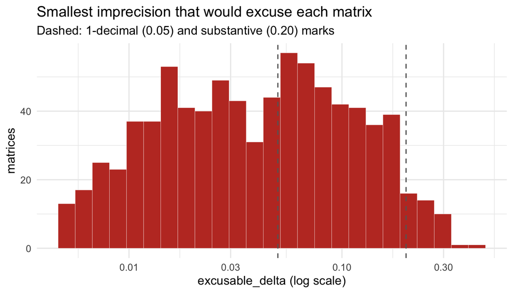

### Where the fault sits, and whether it is benign

```r
deep |>
  count(localization_verdict) |>
  mutate(`%` = round(100 * n / sum(n), 1)) |>
  arrange(desc(n)) |>
  kable(caption = "Localization classes (completed)")
```

Localization classes (completed)

| localization_verdict | n | % |
| --- | --- | --- |
| diffuse | 384 | 47.3 |
| cell | 152 | 18.7 |
| cell_tentative | 96 | 11.8 |
| variable | 86 | 10.6 |
| triad | 77 | 9.5 |
| joint | 16 | 2.0 |

```r
deep |>
  count(severity_class) |>
  mutate(`%` = round(100 * n / sum(n), 1)) |>
  kable(caption = "Structural severity class (completed)")
```

Structural severity class (completed)

| severity_class | n | % |
| --- | --- | --- |
| moderate | 236 | 29.1 |
| near-boundary | 241 | 29.7 |
| substantive | 334 | 41.2 |

## Worked examples

Concrete matrices make the range tangible. We restrict the worked examples to the more **compact** completed matrices (<= 10 variables) so the certificates print legibly, and pull the **most severe** and a **marginal** inconsistency from them.

```r
compact <- deep |> filter(p <= 10) |> arrange(desc(excusable_delta))

if (nrow(compact) < 2) compact <- arrange(deep, desc(excusable_delta))

worst_id    <- compact$id[1]
marginal_id <- compact$id[nrow(compact)]
```

### The most severe inconsistency (compact matrices)

```r
worst <- matrixList[[worst_id]]
cat("source id:", worst_id, "  variables:", nrow(worst), "\n")
```

```
#> source id: JAP-95-2-387|3|59   variables: 5
```

```r
check_corr_psd(worst, decimals = 2)
```

```
#> <corr_psd_check>
#>   verdict : INCONSISTENT  (no PSD matrix fits the rounding box)
#>   tier    : witness
#>   p       : 5      delta : 0.005
#>   corr    : min -0.99  max 0.96  mean 0.111  sd 0.7782  (off-diagonal)
#>   margin  : B = -1.063  (B_upper = -1.063 < 0)
#>   witness : v = (-0.6148, -0.3725, 0.06456, 0.5905, -0.3612)
#>   certificate: v'Rv + delta*(||v||_1^2 - ||v||_2^2) = -1.063 < 0
#>   caution : pairwise deletion, polychoric estimation, meta-analytic
#>             assembly, or upstream disattenuation can legitimately
#>             produce non-PSD reported matrices; see README.
```

```r
localize_psd_fault(worst, decimals = 2)
```

```
#> <psd_fault>
#>   Inconsistent given rounding (delta = 0.005).
#>   Verdict: CELL - Attributable to a single cell
#>     cell (1,4): reported 0.9, but given the other cells (within rounding) it must lie in [-0.945, -0.838];
#>     required edit -1.73, far exceeding the 0.005 rounding tolerance.
#>   Structural: Substantive: no correlation matrix lies within rounding of the reported values (smallest correction is ~85x the rounding step), so it is not explained by rounding of a structural dependency.
#>   Severity: largest single edit needed 0.426 (egregious, rounding cannot excuse it; delta = 0.005);
#>             total mass (Frobenius) 0.918; best achievable lambda_min -1.
#>   Excusable only by mis-reporting beyond +-0.431 per entry -- no conventional rounding precision could excuse it.
#>   Caution: rule out legitimate generators of non-PSD reported matrices
#>   first -- pairwise deletion (per-cell n), polychoric/tetrachoric
#>   estimation, meta-analytically assembled cells, upstream disattenuation.
#>   (The required correction here is ~85x the rounding step, which those
#>   rarely produce.)
#>   - Single sole culprit corroborated by the sparse correction and an inconsistent triple.
#>   - R^2 localizer: variable(s) {1} are over-determined by the others (R^2 > 100%) -- conditional on the other cells being correct.
```

### A marginal inconsistency

Just past the boundary — the kind of thing rounding of an assembled table readily produces:

```r
marginal <- matrixList[[marginal_id]]
cat("source id:", marginal_id, "  variables:", nrow(marginal),
    "  excusable_delta:", round(compact$excusable_delta[nrow(compact)], 4), "\n")
```

```
#> source id: JAP-75-5-467|1|1395   variables: 10   excusable_delta: 0.0051
```

```r
check_corr_psd(marginal, decimals = 2)
```

```
#> <corr_psd_check>
#>   verdict : INCONSISTENT  (no PSD matrix fits the rounding box)
#>   tier    : witness
#>   p       : 10      delta : 0.005
#>   corr    : min -0.34  max 0.95  mean 0.02667  sd 0.2385  (off-diagonal)
#>   margin  : B = -0.0004269  (B_upper = -0.0004269 < 0)
#>   witness : v = ( 0.52, -0.01243, -0.2172, 0.1255, -0.08183, 0.02342, 0.1919, -0.4937, -0.03616, -0.6143)
#>   certificate: v'Rv + delta*(||v||_1^2 - ||v||_2^2) = -0.0004269 < 0
#>   caution : pairwise deletion, polychoric estimation, meta-analytic
#>             assembly, or upstream disattenuation can legitimately
#>             produce non-PSD reported matrices; see README.
```

### A consistent matrix

For contrast, a matrix the screen clears:

```r
ok_id <- screen$id[screen$verdict == "consistent"][1]

check_corr_psd(matrixList[[ok_id]], decimals = 2)
```

```
#> <corr_psd_check>
#>   verdict : CONSISTENT    (certified: in-box PSD matrix exhibited)
#>   tier    : witness
#>   p       : 11      delta : 0.005
#>   corr    : min -0.42  max 0.83  mean 0.1423  sd 0.3041  (off-diagonal)
#>   margin  : B_upper = 0.1174  (>= 0: no inconsistency certificate)
#>   evidence: the reported matrix itself is PSD
```

## Summary

Screen summary

| metric | value |
| --- | --- |
| matrices screened | 12,547 |
| inconsistent | 811 (6.5%) |
| consistent | 93.5% |
| undecided | 0.1% |
| deep dive completed | 811 of 811 |
| completed inconsistencies excusable by 1-decimal reporting (<= 0.05) | 54.6% |

**Reading it.**

The screen assumed two-decimal reporting; matrices in the substantive tail are worth re-checking against their original sources for transcription error, pairwise deletion, or disattenuation before inferring a mistake.